# Project2 Data 612

```r
similarity_items <- similarity(Jester5k[ ,1:5], method = "pearson", which = "items")
as.matrix(similarity_items)
```

```
##           j1        j2        j3        j4        j5
## j1 0.0000000 0.6180590 0.6216113 0.5902784 0.5588692
## j2 0.6180590 0.0000000 0.5795824 0.5999586 0.5625990
## j3 0.6216113 0.5795824 0.0000000 0.6176980 0.5605612
## j4 0.5902784 0.5999586 0.6176980 0.0000000 0.5594754
## j5 0.5588692 0.5625990 0.5605612 0.5594754 0.0000000
```

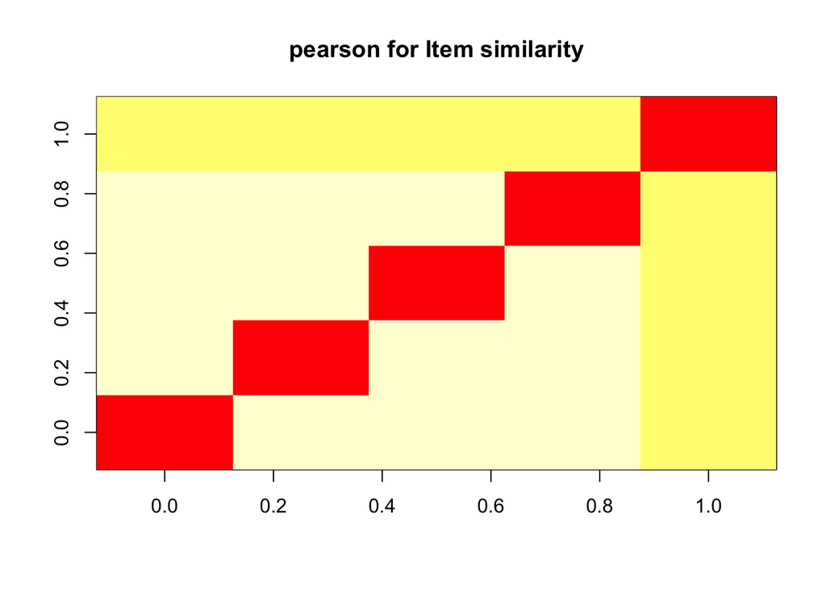

```r
image(as.matrix(similarity_items),main="pearson for Item similarity")
```

I used the same method from comparing users’ similarities to compare the similarities of items. I think cosine seems better again in this case.

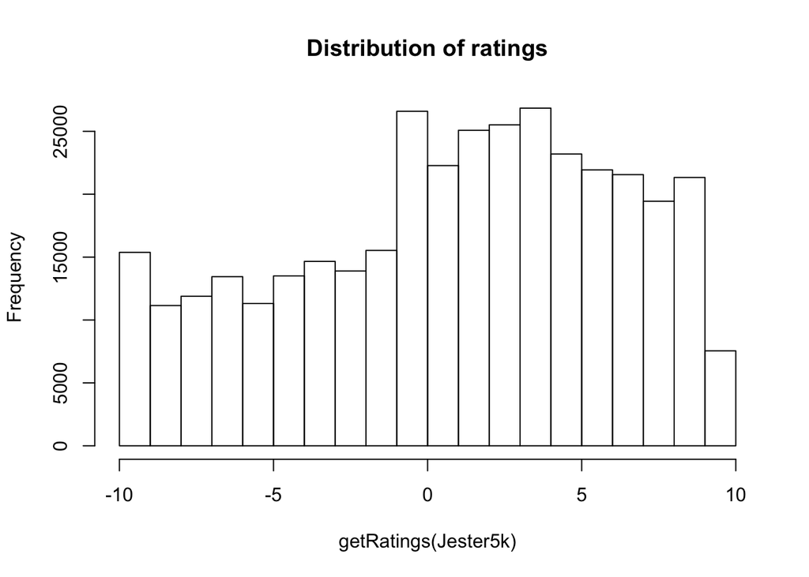

```r
# The histogram for the data

hist(getRatings(Jester5k),main="Distribution of ratings")
```

```r
best <- which.max(colMeans(Jester5k))
cat(JesterJokes[best])
```

```
## A guy goes into confession and says to the priest, "Father, I'm 80 years old, widower, with 11 grandchildren. Last night I met two beautiful flight attendants. They took me home and I made love to both of them. Twice." The priest said: "Well, my son, when was the last time you were in confession?…
```

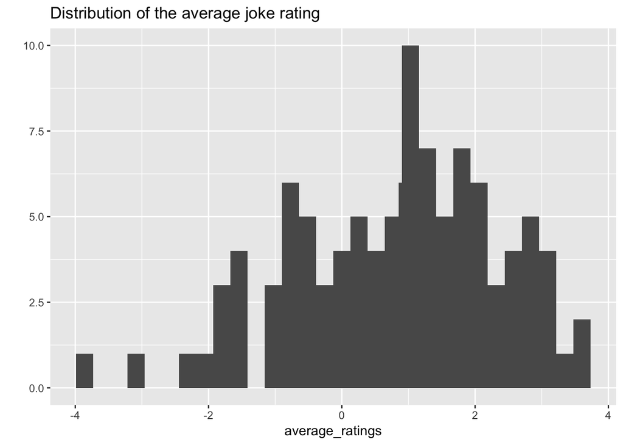

```r
# Exploring the average ratings

average_ratings <- colMeans(Jester5k)
qplot(average_ratings) + stat_bin(binwidth = 0.1) +
   ggtitle("Distribution of the average joke rating")
```

Item-based collaborative filtering. By textbook, the core algorithm is based on these steps 1. For each two items, measure how similar they are in terms of having received similar ratings by similar users. 2. For each item, idenitfy the k-most similar items 3. For each user, identify the items that are most similar to the user’s purchases

building IBCF model 1.Training set and Test set 2.Applying the recommender model on the test set. I will use the model to recommend jokes to the users in the test set and specify 5 jokes to recommend to users.

```r
ratings_jokes <- Jester5k[rowCounts(Jester5k) > 50,
   colCounts(Jester5k) > 100]
# set the probability in the training set as 80%
which_train <- sample(x = c(TRUE, FALSE), size = nrow(ratings_jokes),
   replace = TRUE, prob = c(0.8, 0.2))
head(which_train)
```

```
## [1] TRUE TRUE TRUE TRUE TRUE TRUE
```

```r
# split training and testing set
train <- ratings_jokes[which_train,]
test <- ratings_jokes[!which_train,]

#Remommendation models IBCF
recommender_models <- recommenderRegistry$get_entries(dataType ="realRatingMatrix")
names(recommender_models)
```

```
## [1] "ALS_realRatingMatrix"          "ALS_implicit_realRatingMatrix"
## [3] "IBCF_realRatingMatrix"         "POPULAR_realRatingMatrix"
## [5] "RANDOM_realRatingMatrix"       "RERECOMMEND_realRatingMatrix"
## [7] "SVD_realRatingMatrix"          "SVDF_realRatingMatrix"
## [9] "UBCF_realRatingMatrix"
```

```r
lapply(recommender_models, "[[", "description")
```

```
## $ALS_realRatingMatrix
## [1] "Recommender for explicit ratings based on latent factors, calculated by alternating least squares algorithm."
##
## $ALS_implicit_realRatingMatrix
## [1] "Recommender for implicit data based on latent factors, calculated by alternating least squares algorithm."
##
## $IBCF_realRatingMatrix
## [1] "Recommender based on item-based collaborative filtering."
##
## $POPULAR_realRatingMatrix
## [1] "Recommender based on item popularity."
##
## $RANDOM_realRatingMatrix
## [1] "Produce random recommendations (real ratings)."
##
## $RERECOMMEND_realRatingMatrix
## [1] "Re-recommends highly rated items (real ratings)."
##
## $SVD_realRatingMatrix
## [1] "Recommender based on SVD approximation with column-mean imputation."
##
## $SVDF_realRatingMatrix
## [1] "Recommender based on Funk SVD with gradient descend."
##
## $UBCF_realRatingMatrix
## [1] "Recommender based on user-based collaborative filtering."
```

```r
recommender_models$IBCF_realRatingMatrix$parameters
```

```
## $k
## [1] 30
##
## $method
## [1] "Cosine"
##
## $normalize
## [1] "center"
##
## $normalize_sim_matrix
## [1] FALSE
##
## $alpha
## [1] 0.5
##
## $na_as_zero
## [1] FALSE
```

```r
#Build IBCF Model, model_details$sim is similarity matrix

IBCF_model <- Recommender(data = train, method= "IBCF", parameter = list (k =30))
IBCF_model
```

```
## Recommender of type 'IBCF' for 'realRatingMatrix'
## learned using 3085 users.
```

```r
model_detail <- getModel(IBCF_model)
dim(model_detail$sim)
```

```
## [1] 100 100
```

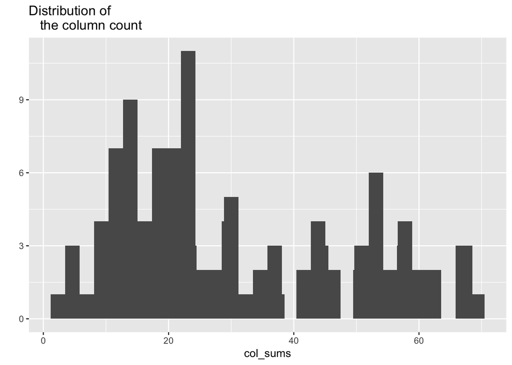

```r
col_sums <- colSums(model_detail$sim > 0)
qplot(col_sums) + stat_bin(binwidth = 1) + ggtitle("Distribution of
   the column count")
```

```r
# In this section, we can find which are the jokes with the most elements.
which_max <- order(col_sums, decreasing = TRUE)[1:6]
rownames(model_detail$sim)[which_max]
```

```
## [1] "j44" "j16" "j57" "j58" "j36" "j53"
```

Applying the recommender model on the test set. (By textbook) 1. Extract the user rating of each purchase associated with this item. The rating is used as as a weight. 2. Extract the similarity of the item with each purchase associated with this item 3. Multiply each weight with the related similarity 4. Sum everything up.

```r
n_recommended <- 5
predict_model <- predict(object = IBCF_model, newdata = test, n = n_recommended)
predict_model
```

```
## Recommendations as 'topNList' with n = 5 for 790 users.
```

```r
class(predict_model)
```

```
## [1] "topNList"
## attr(,"package")
## [1] "recommenderlab"
```

```r
slotNames(predict_model)
```

```
## [1] "items"      "ratings"    "itemLabels" "n"
```

```r
# Example for the first user, recommendations
recc_user_1 <- predict_model@items[[1]]
jokes_user_1 <- predict_model@itemLabels[recc_user_1]
jokes_user_1
```

```
## [1] "j82" "j75" "j94" "j84" "j97"
```

IBCF bases on the similarity matrix. The model stors the 30-most (default number) similar. It will work very will with lots of data and big rating matrices.

3. Building the UBCF model (User based collaborative filtering) By textbook Identify which items are similar in terms of having been purchased by the same people Recommend to a new user the items that are similar to its purchase. 1). Measue how similar each user is to the new one. 2). Identify the most similar users. 3). Rate the items purchased by the most similar users. The rating is the average rating among similar users 4). Pick the top-rated items.

```r
recommender_models <- recommenderRegistry$get_entries(dataType =
   "realRatingMatrix")
recommender_models$UBCF_realRatingMatrix$parameters
```

```
## $method
## [1] "cosine"
##
## $nn
## [1] 25
##
## $sample
## [1] FALSE
##
## $normalize
## [1] "center"
```

```r
UBCF_model <- Recommender(data = train, method = "UBCF")
UBCF_model
```

```
## Recommender of type 'UBCF' for 'realRatingMatrix'
## learned using 3085 users.
```

```r
model_details <- getModel(UBCF_model)
names(model_details)
```

```
## [1] "description" "data"        "method"      "nn"          "sample"
## [6] "normalize"   "verbose"
```

```r
recc_predicted <- predict(object = UBCF_model,
   newdata = test, n = n_recommended)
recc_predicted
```

```
## Recommendations as 'topNList' with n = 5 for 790 users.
```

```r
recc_user_1 <- recc_predicted@items[[1]]
jokes_user_1 <- recc_predicted@itemLabels[recc_user_1]
jokes_user_1
```

```
## [1] "j72"  "j100" "j83"  "j80"  "j73"
```